# Clustering_Bank

# Apply PCA to improve clustering

```python
# apply PCA and display clustering metrics
for y in range(2, 5):
    print("PCA with # of components: ", y)
    pca = PCA(n_components=y)
    data_pca = pca.fit_transform(data_credit_scaled)
    for x in range(2, 7):
        alg = KMeans(n_clusters = x, )
        label = alg.fit_predict(data_pca)
        print('Silhouette-Score for', x,  'Clusters: ', silhouette_score(data_pca, label) , '       Inertia: ',alg.inertia_)
    print()
```

```
PCA with # of components:  2
Silhouette-Score for 2 Clusters:  0.5641633759383394        Inertia:  1837.2357723861
Silhouette-Score for 3 Clusters:  0.663720686897348        Inertia:  786.5386436168999
Silhouette-Score for 4 Clusters:  0.6342855808690568        Inertia:  455.1277518243037
Silhouette-Score for 5 Clusters:  0.7210260169425503        Inertia:  212.56326073574746
Silhouette-Score for 6 Clusters:  0.6390043686196722        Inertia:  153.80062530069796

PCA with # of components:  3
Silhouette-Score for 2 Clusters:  0.46908138286045153        Inertia:  2755.9829993146004
Silhouette-Score for 3 Clusters:  0.5628552312933299        Inertia:  1587.2678651903548
Silhouette-Score for 4 Clusters:  0.6576041191678578        Inertia:  722.4580310557122
Silhouette-Score for 5 Clusters:  0.7069339351958316        Inertia:  347.6450283403399
Silhouette-Score for 6 Clusters:  0.6376887787357601        Inertia:  265.96603188941276

PCA with # of components:  4
Silhouette-Score for 2 Clusters:  0.4383791421555834        Inertia:  2945.331711280388
Silhouette-Score for 3 Clusters:  0.5259390198898544        Inertia:  1776.5238975542977
Silhouette-Score for 4 Clusters:  0.6049326456425035        Inertia:  909.4634423218092
Silhouette-Score for 5 Clusters:  0.6317879155884448        Inertia:  529.1714499919367
Silhouette-Score for 6 Clusters:  0.5478247417594113        Inertia:  441.5605673662874
```

```python
# Looks like 2 PCA components with 5-6 clusters will give us optimal results for KMeans
```

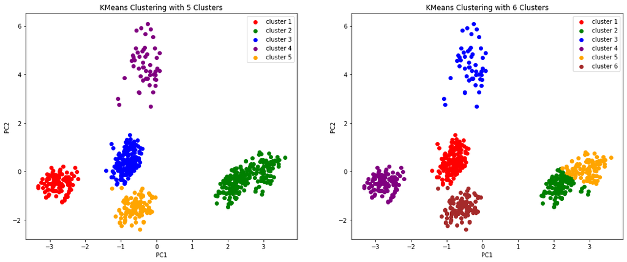

```python
# Visualizing the PCA
data_pca = pd.DataFrame(PCA(n_components = 2).fit_transform(data_credit_scaled))
preds = pd.Series(KMeans(n_clusters = 5,).fit_predict(data_pca))
data_pca = pd.concat([data_pca, preds], axis =1)
data_pca.columns = [0,1,'target']

fig = plt.figure(figsize = (18, 7))
colors = ['red', 'green', 'blue', 'purple', 'orange', 'brown']
plt.subplot(121)
plt.scatter(data_pca[data_pca['target']==0].iloc[:,0], data_pca[data_pca.target==0].iloc[:,1], c = colors[0], label = 'cluster 1')
plt.scatter(data_pca[data_pca['target']==1].iloc[:,0], data_pca[data_pca.target==1].iloc[:,1], c = colors[1], label = 'cluster 2')
plt.scatter(data_pca[data_pca['target']==2].iloc[:,0], data_pca[data_pca.target==2].iloc[:,1], c = colors[2], label = 'cluster 3')
plt.scatter(data_pca[data_pca['target']==3].iloc[:,0], data_pca[data_pca.target==3].iloc[:,1], c = colors[3], label = 'cluster 4')
plt.scatter(data_pca[data_pca['target']==4].iloc[:,0], data_pca[data_pca.target==4].iloc[:,1], c = colors[4], label = 'cluster 5')
plt.legend()
plt.title('KMeans Clustering with 5 Clusters')
plt.xlabel('PC1')
plt.ylabel('PC2')


data_pca = pd.DataFrame(PCA(n_components = 2).fit_transform(data_credit_scaled))
preds = pd.Series(KMeans(n_clusters = 6,).fit_predict(data_pca))
data_pca = pd.concat([data_pca, preds], axis =1)
data_pca.columns = [0,1,'target']

plt.subplot(122)
plt.scatter(data_pca[data_pca['target']==0].iloc[:,0], data_pca[data_pca.target==0].iloc[:,1], c = colors[0], label = 'cluster 1')
plt.scatter(data_pca[data_pca['target']==1].iloc[:,0], data_pca[data_pca.target==1].iloc[:,1], c = colors[1], label = 'cluster 2')
plt.scatter(data_pca[data_pca['target']==2].iloc[:,0], data_pca[data_pca.target==2].iloc[:,1], c = colors[2], label = 'cluster 3')
plt.scatter(data_pca[data_pca['target']==3].iloc[:,0], data_pca[data_pca.target==3].iloc[:,1], c = colors[3], label = 'cluster 4')
plt.scatter(data_pca[data_pca['target']==4].iloc[:,0], data_pca[data_pca.target==4].iloc[:,1], c = colors[4], label = 'cluster 5')
plt.scatter(data_pca[data_pca['target']==5].iloc[:,0], data_pca[data_pca.target==5].iloc[:,1], c = colors[5], label = 'cluster 6')
plt.legend()
plt.title('KMeans Clustering with 6 Clusters')
plt.xlabel('PC1')
plt.ylabel('PC2')
```

# Hierarchical Clustering with PCA

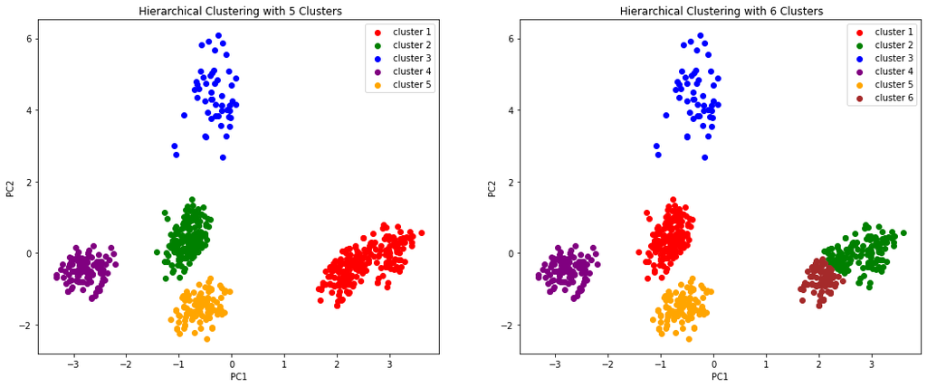

```python
data_pca = pd.DataFrame(PCA(n_components = 2).fit_transform(data_credit_scaled))
preds = pd.Series(AgglomerativeClustering(n_clusters = 5,).fit_predict(data_pca))
data_pca = pd.concat([data_pca, preds], axis =1)
data_pca.columns = [0,1,'target']

fig = plt.figure(figsize = (18, 7))
colors = ['red', 'green', 'blue', 'purple', 'orange', 'brown']
plt.subplot(121)
plt.scatter(data_pca[data_pca['target']==0].iloc[:,0], data_pca[data_pca.target==0].iloc[:,1], c = colors[0], label = 'cluster 1')
plt.scatter(data_pca[data_pca['target']==1].iloc[:,0], data_pca[data_pca.target==1].iloc[:,1], c = colors[1], label = 'cluster 2')
plt.scatter(data_pca[data_pca['target']==2].iloc[:,0], data_pca[data_pca.target==2].iloc[:,1], c = colors[2], label = 'cluster 3')
plt.scatter(data_pca[data_pca['target']==3].iloc[:,0], data_pca[data_pca.target==3].iloc[:,1], c = colors[3], label = 'cluster 4')
plt.scatter(data_pca[data_pca['target']==4].iloc[:,0], data_pca[data_pca.target==4].iloc[:,1], c = colors[4], label = 'cluster 5')
plt.legend()
plt.title(' Hierarchical Clustering with 5 Clusters')
plt.xlabel('PC1')
plt.ylabel('PC2')


data_pca = pd.DataFrame(PCA(n_components = 2).fit_transform(data_credit_scaled))
preds = pd.Series(AgglomerativeClustering(n_clusters = 6,).fit_predict(data_pca))
data_pca = pd.concat([data_pca, preds], axis =1)
data_pca.columns = [0,1,'target']

plt.subplot(122)
plt.scatter(data_pca[data_pca['target']==0].iloc[:,0], data_pca[data_pca.target==0].iloc[:,1], c = colors[0], label = 'cluster 1')
plt.scatter(data_pca[data_pca['target']==1].iloc[:,0], data_pca[data_pca.target==1].iloc[:,1], c = colors[1], label = 'cluster 2')
plt.scatter(data_pca[data_pca['target']==2].iloc[:,0], data_pca[data_pca.target==2].iloc[:,1], c = colors[2], label = 'cluster 3')
plt.scatter(data_pca[data_pca['target']==3].iloc[:,0], data_pca[data_pca.target==3].iloc[:,1], c = colors[3], label = 'cluster 4')
plt.scatter(data_pca[data_pca['target']==4].iloc[:,0], data_pca[data_pca.target==4].iloc[:,1], c = colors[4], label = 'cluster 5')
plt.scatter(data_pca[data_pca['target']==5].iloc[:,0], data_pca[data_pca.target==5].iloc[:,1], c = colors[5], label = 'cluster 6')
plt.legend()
plt.title(' Hierarchical Clustering with 6 Clusters')
plt.xlabel('PC1')
plt.ylabel('PC2')
```

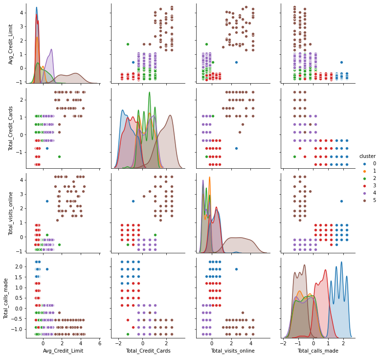

```python
# Dendrogram and cophenetic coeff.
# select best columns with 6 clusters
best_cols = ["Avg_Credit_Limit", "Total_Credit_Cards", "Total_visits_online", "Total_calls_made"]

# apply KMeans clustering
alg = KMeans(n_clusters = 6)
label = alg.fit_predict(data_credit_scaled)

# create a 'cluster' column
data_credit_scaled['cluster'] = label
best_cols.append('cluster')

# make a Seaborn pairplot
sns.pairplot(data_credit_scaled[best_cols], hue='cluster')
```

```python
# Build the Clusters cluster 1
clus1 = linkage(data_credit_scaled, method = 'average')
```

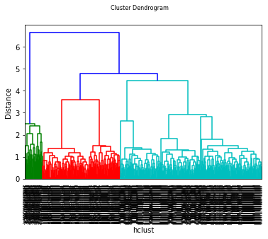

```python
# Display the Clusters in Dendogram
dendrogram(clus1, labels=data_credit_scaled["Total_visits_bank"].values.tolist())
plt.xlabel('hclust')
plt.ylabel('Distance')
plt.suptitle('Cluster Dendrogram', fontsize = 8)
```

```python
# eucilidean cluster
d_euc2 = pdist(data_credit_scaled.iloc[:,2:7], metric = 'euclidean')
print(np.round(squareform(d_euc2).tolist(),3))
```

```
[[0.    5.26  1.555 ... 4.19  5.725 4.992]
 [5.26  0.    4.138 ... 5.857 6.258 5.696]
 [1.555 4.138 0.    ... 3.909 5.356 4.503]
 ...
 [4.19  5.857 3.909 ... 0.    2.075 1.243]
 [5.725 6.258 5.356 ... 2.075 0.    1.382]
 [4.992 5.696 4.503 ... 1.243 1.382 0.   ]]
```

```python
# cluster 2
clus2 = linkage(pdist(data.iloc[:,2:7], metric = 'euclidean'), method = 'average')
distance = clus2[:,2]
distance
```

[output not shown]

[output cut: 110 more lines]

```
       1.50000412e+03, 1.50000485e+03, 1.50000537e+03, 1.54545858e+03,
       1.60001051e+03, 1.75000337e+03, 1.81631717e+03, 1.83334310e+03,
       1.87301925e+03, 2.00000150e+03, 2.00000750e+03, 2.00001325e+03,
       2.07143159e+03, 2.10000249e+03, 2.20146830e+03, 2.22460186e+03,
       2.25000953e+03, 2.43403176e+03, 2.44541917e+03, 2.50000092e+03,
       2.59615922e+03, 2.70833587e+03, 3.00000668e+03, 3.01389329e+03,
       3.33333585e+03, 3.38714330e+03, 3.40000256e+03, 3.60588409e+03,
       3.77976339e+03, 3.89091065e+03, 4.00000590e+03, 4.11904925e+03,
       4.50000104e+03, 4.50000382e+03, 4.53774472e+03, 4.65000149e+03,
       5.00000070e+03, 5.00000185e+03, 5.33333743e+03, 5.57500127e+03,
       6.37554219e+03, 6.66666991e+03, 8.05052926e+03, 8.66666828e+03,
       8.75000104e+03, 8.78655563e+03, 9.58408555e+03, 1.08333340e+04,
       1.16666682e+04, 1.30000018e+04, 1.53666681e+04, 1.54296071e+04,
       1.75050512e+04, 2.33714139e+04, 2.81500005e+04, 2.86470595e+04,
       4.41829756e+04, 6.14398151e+04, 1.14509515e+05])
```

```python
# Profiling the clusters
data_credit_scaled['Clusters'] = cut_tree(clus2,2)
clus_profile = data_credit_scaled.iloc[:,2:8].groupby(['Clusters'],as_index=False).mean()
clus_profile
```

|  | Clusters | Total_visits_bank | Total_visits_online | Total_calls_made | group | cluster |
| --- | --- | --- | --- | --- | --- | --- |
| 0 | 0 | -1.100953 | 2.761147 | -0.881726 | 1.980392 | 4.941176 |
| 1 | 1 | 0.092198 | -0.231229 | 0.073839 | 2.392447 | 1.894910 |

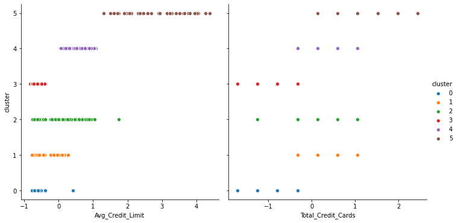

```python
# Plot credit limit and Total credit cards..
sns.pairplot(data_credit_scaled[best_cols], hue='cluster', x_vars=['Avg_Credit_Limit', 'Total_Credit_Cards'],
            y_vars=['cluster'],
            height=5, aspect=1)
```

[figure not shown]

```python
sns.pairplot(data_imputed[best_cols], hue='cluster', x_vars=['Total_visits_online'], y_vars=['Total_calls_made'],
            height=5, aspect=1)
```

How many different segments of customers are there? 6 different segements of customers.

How are these segments different from each other?.

The blue segement of users, while having the highest number of users ,they have lowest ave credit limit and lesser credit cards.

What are your recommendations to the bank on how to better market to and service these customers? Target more customers which have low number of credit cards.